# Risk Factor Analysis

## Outcome Variable

**Outcome Variable:** whz

## Predictor Variables

**Intervention Variable:** month

**Adjustment Set:**

unadjusted

## Stratifying Variables

The analysis was stratified on these variable(s):

- agecat

## Data Summary

| agecat | month | n_cell | n |
| --- | --- | --- | --- |
| Birth | 1 | 3752 | 45322 |
| Birth | 2 | 3292 | 45322 |
| Birth | 3 | 3888 | 45322 |
| Birth | 4 | 3334 | 45322 |
| Birth | 5 | 2900 | 45322 |
| Birth | 6 | 3099 | 45322 |
| Birth | 7 | 3529 | 45322 |
| Birth | 8 | 3889 | 45322 |
| Birth | 9 | 4319 | 45322 |
| Birth | 10 | 4360 | 45322 |
| Birth | 11 | 4348 | 45322 |
| Birth | 12 | 4612 | 45322 |
| 6 months | 1 | 4220 | 56736 |
| 6 months | 2 | 3804 | 56736 |
| 6 months | 3 | 4597 | 56736 |
| 6 months | 4 | 4639 | 56736 |
| 6 months | 5 | 4317 | 56736 |
| 6 months | 6 | 4186 | 56736 |
| 6 months | 7 | 4979 | 56736 |
| 6 months | 8 | 5224 | 56736 |
| 6 months | 9 | 5313 | 56736 |
| 6 months | 10 | 5100 | 56736 |
| 6 months | 11 | 5105 | 56736 |
| 6 months | 12 | 5252 | 56736 |
| 24 months | 1 | 1414 | 22883 |
| 24 months | 2 | 1736 | 22883 |
| 24 months | 3 | 1976 | 22883 |
| 24 months | 4 | 2115 | 22883 |
| 24 months | 5 | 1717 | 22883 |
| 24 months | 6 | 1632 | 22883 |
| 24 months | 7 | 2261 | 22883 |
| 24 months | 8 | 2045 | 22883 |
| 24 months | 9 | 2068 | 22883 |
| 24 months | 10 | 1879 | 22883 |
| 24 months | 11 | 1907 | 22883 |
| 24 months | 12 | 2133 | 22883 |

The following strata were considered:

- agecat: 24 months
- agecat: 6 months
- agecat: Birth

## Methods Detail

We’re interested in the causal parameters $E[Y_a]$ for all values of $a \in \mathcal{A}$. These parameters represent the mean outcome if, possibly contrary to fact, we intervened to set all units to have $A=a$. Under the randomization and positivity assumptions, these are identified by the statistical parameters $\psi_a=E_W[E_{Y|A,W}(Y|A=a,W)]$. In addition, we’re interested in the mean of $Y$, $E[Y]$ under no intervention (the observed mean). We will estimate these parameters by using SuperLearner to fit the relevant likelihood factors – $E_{Y|A,W}(Y|A=a,W)$ and $p(A=a|W)$, and then updating our likelihood fit using a joint TMLE.

For unadjusted analyses ($W=\{\}$), initial likelihoods were estimated using Lrnr_glm to estimate the simple $E(Y|A)$ and Lrnr_mean to estimate $p(A)$. For adjusted analyses, a small library containing Lrnr_glmnet, Lrnr_xgboost, and Lrnr_mean was used.

Having estimated these parameters, we will then use the delta method to estimate relative risks and attributable risks relative to a prespecified baseline level of $A$.

# Results Detail

## Results Plots

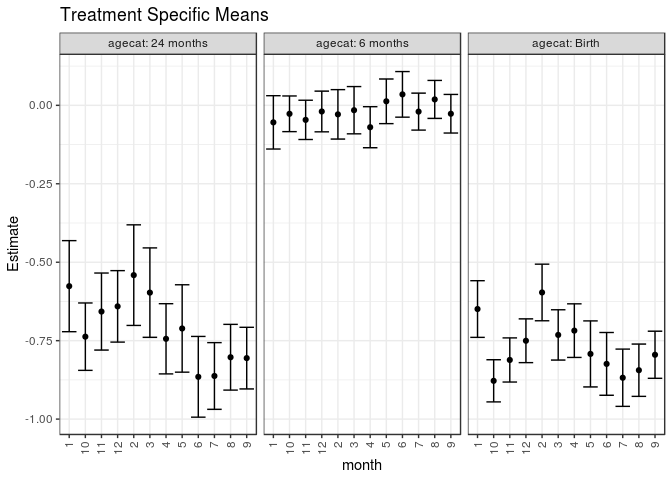

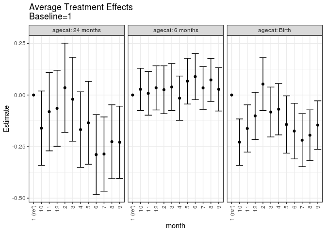

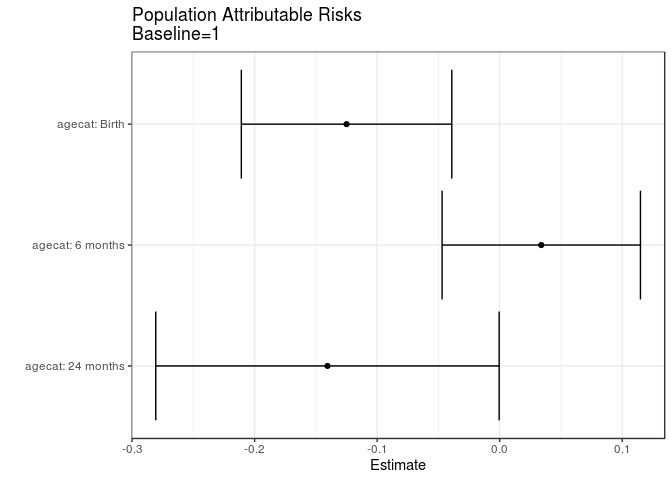

## Results Table

### Parameter: TSM

| agecat | intervention_level | baseline_level | estimate | ci_lower | ci_upper |
| --- | --- | --- | --- | --- | --- |
| Birth | 1 | NA | -0.6491658 | -0.7394493 | -0.5588822 |
| Birth | 2 | NA | -0.5963609 | -0.6865923 | -0.5061295 |
| Birth | 3 | NA | -0.7316487 | -0.8118083 | -0.6514890 |
| Birth | 4 | NA | -0.7180024 | -0.8034400 | -0.6325648 |
| Birth | 5 | NA | -0.7921897 | -0.8974233 | -0.6869560 |
| Birth | 6 | NA | -0.8239852 | -0.9240300 | -0.7239403 |
| Birth | 7 | NA | -0.8681354 | -0.9593748 | -0.7768961 |
| Birth | 8 | NA | -0.8441322 | -0.9274596 | -0.7608048 |
| Birth | 9 | NA | -0.7948993 | -0.8699662 | -0.7198323 |
| Birth | 10 | NA | -0.8779633 | -0.9451529 | -0.8107737 |
| Birth | 11 | NA | -0.8114673 | -0.8818268 | -0.7411078 |
| Birth | 12 | NA | -0.7502710 | -0.8200524 | -0.6804897 |
| 6 months | 1 | NA | -0.0542552 | -0.1392313 | 0.0307209 |
| 6 months | 2 | NA | -0.0287437 | -0.1075275 | 0.0500401 |
| 6 months | 3 | NA | -0.0155195 | -0.0908252 | 0.0597862 |
| 6 months | 4 | NA | -0.0697568 | -0.1351118 | -0.0044019 |
| 6 months | 5 | NA | 0.0128359 | -0.0582816 | 0.0839535 |
| 6 months | 6 | NA | 0.0349365 | -0.0376919 | 0.1075649 |
| 6 months | 7 | NA | -0.0200094 | -0.0789110 | 0.0388923 |
| 6 months | 8 | NA | 0.0188814 | -0.0416274 | 0.0793902 |
| 6 months | 9 | NA | -0.0267943 | -0.0882841 | 0.0346956 |
| 6 months | 10 | NA | -0.0270037 | -0.0838233 | 0.0298159 |
| 6 months | 11 | NA | -0.0463247 | -0.1088603 | 0.0162109 |
| 6 months | 12 | NA | -0.0196259 | -0.0845252 | 0.0452734 |
| 24 months | 1 | NA | -0.5763013 | -0.7214051 | -0.4311974 |
| 24 months | 2 | NA | -0.5411799 | -0.7014564 | -0.3809034 |
| 24 months | 3 | NA | -0.5968446 | -0.7393450 | -0.4543443 |
| 24 months | 4 | NA | -0.7440642 | -0.8559351 | -0.6321934 |
| 24 months | 5 | NA | -0.7111396 | -0.8503849 | -0.5718943 |
| 24 months | 6 | NA | -0.8652032 | -0.9938502 | -0.7365563 |
| 24 months | 7 | NA | -0.8625092 | -0.9688076 | -0.7562108 |
| 24 months | 8 | NA | -0.8028142 | -0.9075652 | -0.6980632 |
| 24 months | 9 | NA | -0.8055730 | -0.9038160 | -0.7073300 |
| 24 months | 10 | NA | -0.7372441 | -0.8446361 | -0.6298521 |
| 24 months | 11 | NA | -0.6571932 | -0.7799378 | -0.5344486 |
| 24 months | 12 | NA | -0.6406825 | -0.7545832 | -0.5267818 |

### Parameter: E(Y)

| agecat | intervention_level | baseline_level | estimate | ci_lower | ci_upper |
| --- | --- | --- | --- | --- | --- |
| Birth | NA | NA | -0.7741124 | -0.7976489 | -0.7505758 |
| 6 months | NA | NA | -0.0203084 | -0.0394517 | -0.0011651 |
| 24 months | NA | NA | -0.7168385 | -0.7517602 | -0.6819168 |

### Parameter: ATE

| agecat | intervention_level | baseline_level | estimate | ci_lower | ci_upper |
| --- | --- | --- | --- | --- | --- |
| Birth | 1 | 1 | 0.0000000 | 0.0000000 | 0.0000000 |
| Birth | 2 | 1 | 0.0528049 | -0.0750329 | 0.1806427 |
| Birth | 3 | 1 | -0.0824829 | -0.2034077 | 0.0384419 |
| Birth | 4 | 1 | -0.0688366 | -0.1933437 | 0.0556704 |
| Birth | 5 | 1 | -0.1430239 | -0.2818914 | -0.0041563 |
| Birth | 6 | 1 | -0.1748194 | -0.3097092 | -0.0399295 |
| Birth | 7 | 1 | -0.2189697 | -0.3474598 | -0.0904795 |
| Birth | 8 | 1 | -0.1949664 | -0.3179791 | -0.0719537 |
| Birth | 9 | 1 | -0.1457335 | -0.2633457 | -0.0281213 |
| Birth | 10 | 1 | -0.2287975 | -0.3414809 | -0.1161142 |
| Birth | 11 | 1 | -0.1623016 | -0.2768845 | -0.0477186 |
| Birth | 12 | 1 | -0.1011053 | -0.2153460 | 0.0131355 |
| 6 months | 1 | 1 | 0.0000000 | 0.0000000 | 0.0000000 |
| 6 months | 2 | 1 | 0.0255114 | -0.0906377 | 0.1416605 |
| 6 months | 3 | 1 | 0.0387357 | -0.0749887 | 0.1524601 |
| 6 months | 4 | 1 | -0.0155016 | -0.1229175 | 0.0919142 |
| 6 months | 5 | 1 | 0.0670911 | -0.0438211 | 0.1780033 |
| 6 months | 6 | 1 | 0.0891917 | -0.0226997 | 0.2010830 |
| 6 months | 7 | 1 | 0.0342458 | -0.0693259 | 0.1378175 |
| 6 months | 8 | 1 | 0.0731366 | -0.0314026 | 0.1776757 |
| 6 months | 9 | 1 | 0.0274609 | -0.0775156 | 0.1324374 |
| 6 months | 10 | 1 | 0.0272514 | -0.0750791 | 0.1295820 |
| 6 months | 11 | 1 | 0.0079305 | -0.0977551 | 0.1136161 |
| 6 months | 12 | 1 | 0.0346293 | -0.0724219 | 0.1416804 |
| 24 months | 1 | 1 | 0.0000000 | 0.0000000 | 0.0000000 |
| 24 months | 2 | 1 | 0.0351214 | -0.1810538 | 0.2512966 |
| 24 months | 3 | 1 | -0.0205434 | -0.2238746 | 0.1827879 |
| 24 months | 4 | 1 | -0.1677630 | -0.3509688 | 0.0154429 |
| 24 months | 5 | 1 | -0.1348383 | -0.3358191 | 0.0661425 |
| 24 months | 6 | 1 | -0.2889020 | -0.4827170 | -0.0950869 |
| 24 months | 7 | 1 | -0.2862079 | -0.4661344 | -0.1062815 |
| 24 months | 8 | 1 | -0.2265129 | -0.4054922 | -0.0475336 |
| 24 months | 9 | 1 | -0.2292717 | -0.4045194 | -0.0540241 |
| 24 months | 10 | 1 | -0.1609428 | -0.3413031 | 0.0194174 |
| 24 months | 11 | 1 | -0.0808920 | -0.2708117 | 0.1090278 |
| 24 months | 12 | 1 | -0.0643813 | -0.2487089 | 0.1199464 |

### Parameter: PAR

| agecat | intervention_level | baseline_level | estimate | ci_lower | ci_upper |
| --- | --- | --- | --- | --- | --- |
| Birth | 1 | NA | -0.1249466 | -0.2108154 | -0.0390777 |
| 6 months | 1 | NA | 0.0339468 | -0.0469901 | 0.1148837 |
| 24 months | 1 | NA | -0.1405372 | -0.2806400 | -0.0004345 |